# Assignment3

Elena Simion

2026-09-27

# 1 Overview and set-up

In this week’s assignment we will use the same NHANES data (provided as cleaned_NHANES.csv) and a new diet data (diet.csv). The exercises will revolve around presenting a visual understanding of our data.

## 1.1 Package loading and data importing

The following code is used to load necessary packages and import the data used.

```r
library(pacman)
p_load(rio, here, tidyverse,
       ggrepel, ggplot2, cowplot, ggpubr)

#data for exercises 1 and 2
cleaned_NHANES <- import(here("Data", "cleaned_NHANES.csv"))

#data for exercise 3
diet_data <- import(here("Data", "diet.csv"))
```

# 2 Reproducing and arranging ggplot figures

In this following section, we will first reproduce two figures using the cleaned_NHANES data. It was necessary to filter the data and keep only the information of participants 21 years and older. This selection is kept in all following sections using data from cleaned_NHANES.

## 2.1 Reproduced figures

### 2.1.1 First figure: age vs sex

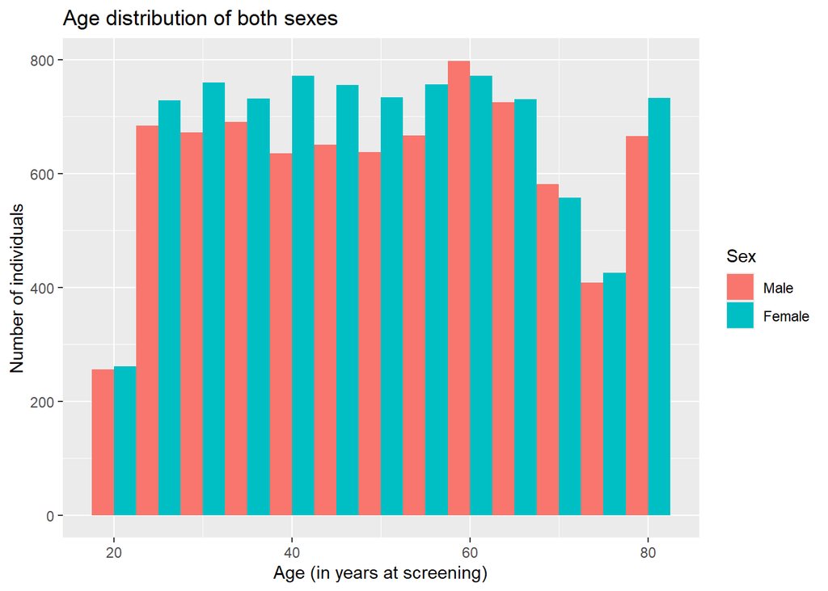

### 2.1.2 Second figure: ethnicity vs sex

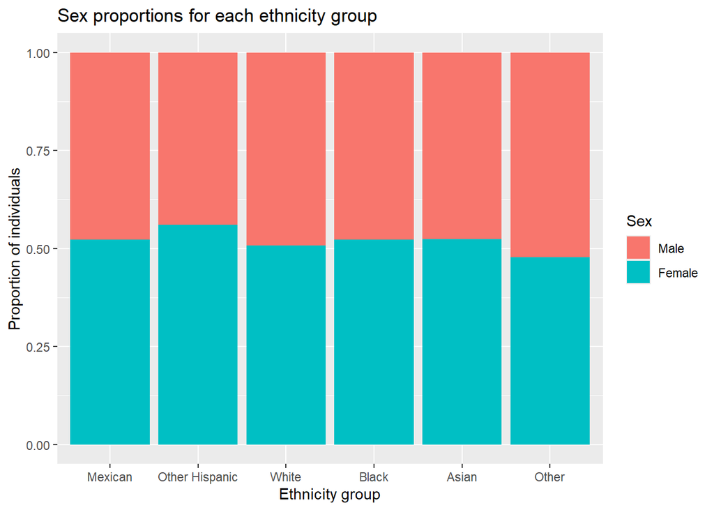

## 2.2 Combining figures in a single output

With these two figures, we will compare plot_grid() and ggarrange() function by combining both figures in a single output using each function. The two plots are below this section.

In comparison, these two functions do very similar results but have each their strengths and weaknesses:

- plot arrangement: plot_grid() allows precisely organized plots in a common space, with easy access to change labels and legends. Great for complex plot combinations.
- unification : ggarrange() allows a quick fusion between plots, especially if they have common legends (as in our case) thanks to common.legend argument.

I find that using ggarrange() function is best in this case. We are not expecting a complex arrangement of our figures and we have a common legend that can be unified with ggarrange().

### 2.2.1 Using plot_grid()

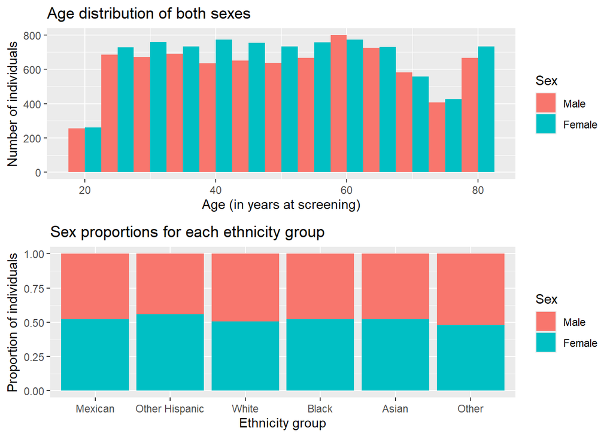

### 2.2.2 Using ggarrange()

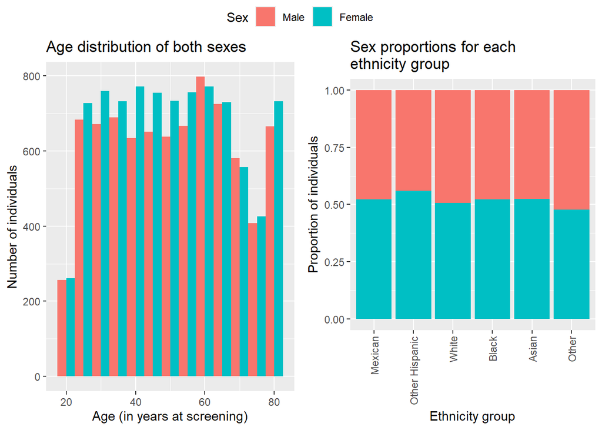

# 3 Visualizing key characteristics

In this second exercise, we will focus on creating appropriate plots to maximize the representation of key characteristics that we want to convey. We will be using once more the NHANES data, displayed below:

[output not shown]

[output cut: 29390 more lines]

## 3.1 Four plots

Below are four plots created to bring a visual representation of important variables in our data. They are each explained and analysed afterwards.

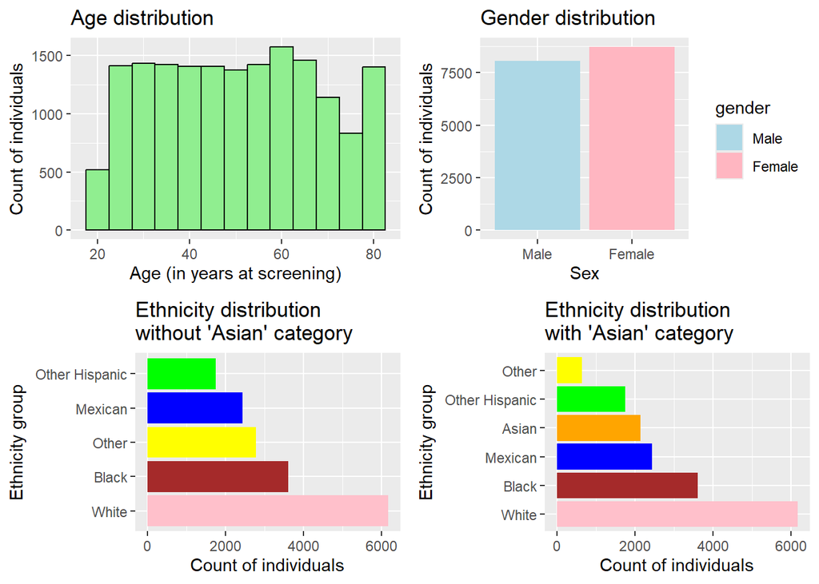

```r
all_four <- ggarrange(age_plot, sex_plot, ethnicity1_plot, ethnicity2_plot)
all_four
```

When checking for missing values in the variables we used, no missing value is found. Here is the code used to find missing values:

```r
#check for missing values
sum(is.na(filtered_adult$age))
sum(is.na(filtered_adult$sex))
sum(is.na(filtered_adult$ethnicity_1))
sum(is.na(filtered_adult$ethnicity_2))
```

[output not shown]

## 3.3 Choice of ethnicity variable

I find that keeping the second ethnicity variable (ethnicity2) is more interesting because it provides us with a wider understanding of our data, instead of keeping variables in a unclear, “Other”, category. Though too much information can eventually complicate figure readability, I find that in our case, adding this one detail would allow a more revealing data analysis.

# 4 Improving ggplot figure

Here, we will improve a figure that uses the diet data. It is meant to show weight progression of 20 individuals, after 16 weeks.

## 4.2 Improved figure

The following figure allows an easier reading of the weight change in participant after 16 weeks. There are a few drawbacks explained below the figure, but none affect the intended message of the figure.

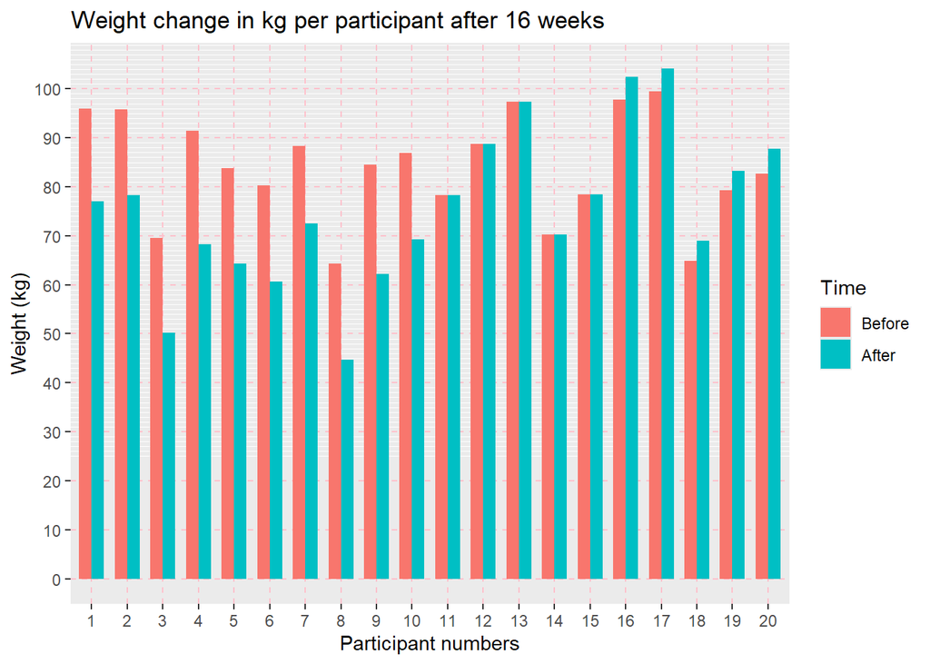

Drawbacks:

- We do not see the evolution shape of weight loss or weight gain. However, in all participants, if there is an evolution in their weight, this evolution is always linear. Therefore seeing how the evolution happened isn’t of much interest.
- The amount of participants weight change, if there is any, could have been more emphasized. However, when I tried to show a weight change value, I couldn’t integrate the multiple variables that we want to show (such as original weight, final weight, participant id) without clustering.
- In a different figure, I presented participants by weight change (gained, lost, maintained) and I noticed 3 trends : small weight gain, vs big weight loss, vs maintained weight. These trends would have been interesting to be presented depending on what the diet data actually means (it could have been a comparison between study groups). However, I chose not to categorize participants by weight progression to ease the figure’s reading based on the idea that we want to quickly find one participant at a time.

# 5 Exploring relationship through visualizations

The purpose of this last section is to explore the relationship between age, gender, and systolic blood pressure (SBP) while balancing text and visualization.

## 5.1 Preparing data: Relationships between variables

To explore the relationship between variables in our data, we begin by organizing and setting up our wanted variables. Age and gender variables are already suited for visualization, we will therefore prepare SBP data.

### 5.1.1 SBP data manipulation

In our main cleaned_NHANES data, we have four readings of SBP. To ease presentation and understanding of these readings, we will go through three following steps :

- First: create an average SPB variable for each individuals (leaving a missing value only if all four SBP readings are missing)
- Second: make a separate dataset that includes only individuals that have all values for age, gender, and average SBP.
- Last: classify SBP values into categories that explain average SBP value.

### 5.1.2 Sample visual description

With our selected data now ready, we can describe the distribution of various variables in our final sample and if needed, compare it with the original sample size. We keep in mind that our original cleaned_NHANES data (excluding participants younger than 21 years old) can be significantly larger than our selected data due to rows with missing data.

Below, we will find the distribution in hypertension categories, the distribution in gender, and the comparison of age distribution between our original data and our selected data.

[figure not shown]

Despite the selection made, we see above that there hasn’t been any preferential selection due to missing data. There seems to have been only a diminution in data size. This is a very good sign, meaning that our selected data presents a wide variety of subjects and will permit a proper investigation on the relationships between average SBP and various variables such as age or gender.

## 5.2 Visual: Relationships between variables

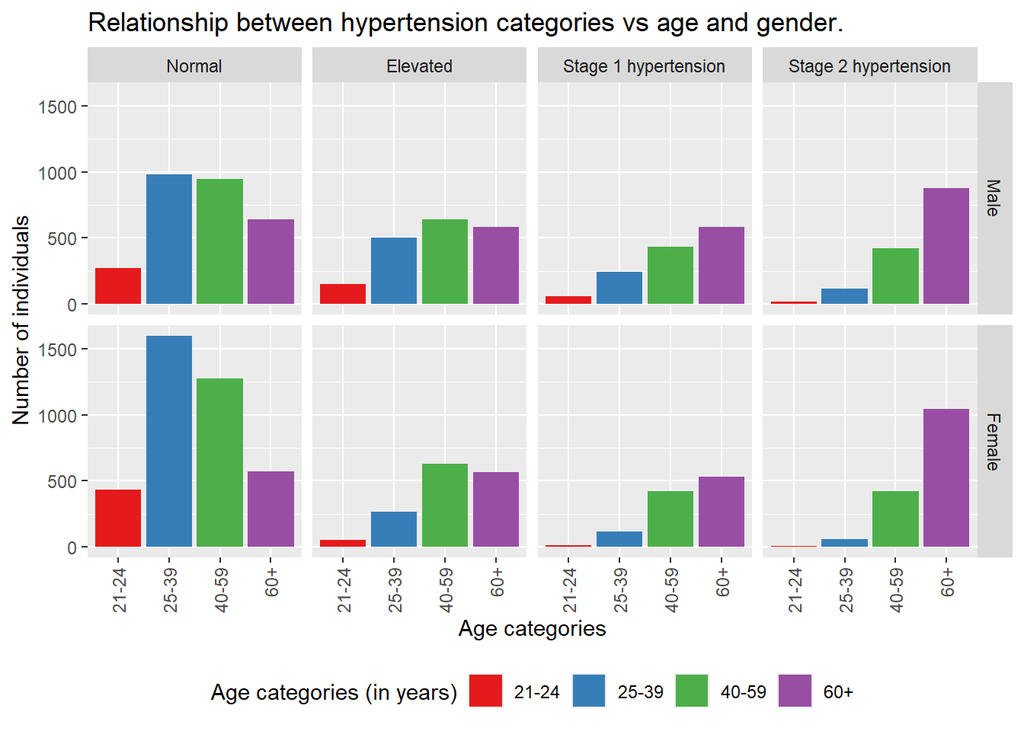

Following this facet grid, we can notice multiple aspects of the relationship between hypertension categories and sex and age.

### 5.2.1 Hypertension categories in relationship with age

Concerning the number of individuals from each age category, we notice that all but age category “60 +” decrease after each hypertension category, in both male and female. Indeed, the number of individuals in age category “60 +”, for both male and female, seem to remain almost similar for the first three hypertension categories, but almost double once in the “Stage 2 hypertension” category. We can infer that individuals over 60 years old might be more susceptible to have “Stage 2 hypertension” than younger individuals.

### 5.2.2 Hypertension categories in relationship with sex

Concerning the number of individuals from both sexes, we notice that females, contrarily to males, seem to have a higher total number in the “Normal” category. However, we also notice that there seem to be, in total, more females in the “Stage 2 hypertension” category than males. We can infer that females have more contrasted hypertension symptoms than males.

End